# Descargar, importar (y exportar) datos con R

Curso de Introducción a R (SFPIE)  
(Web del curso [aquí](https://perezp44.github.io/intro.R.sfpie.2025.web/))

# Descargar datos con R

¿Cómo solemos descargar unos datos?

- Depende de donde estén, pero lo normal es que los datos se descarguen **pinchando en un enlace**.
- Por ejemplo, en la siguiente ruta hay un fichero de datos en formato `.xlsx`:  
  https://www.ine.es/daco/daco42/codmun/codmun20/20codmun.xlsx
- ¿Donde se descargarán esos datos?

¿Y cómo se descargan datos con R?

- Usando código
- Al principio es un poco más complicado, pero **tiene ventajas**, y además estamos aprendiendo R
- Veámoslo con un ejemplo

Tarea: descargar un fichero de datos con R

- Tarea
- Pistas
- Solución (I)
- Solución (II)
- (Extended solution)
- En esta dirección hay un fichero de datos en formato `.csv`:  
  https://raw.githubusercontent.com/perezp44/archivos_download/refs/heads/master/plazas_turisticas.csv
- Intenta descargar el fichero con R.
- En los siguientes “Tabs” tienes **pistas** y luego **la solución**
1. Usaremos la función `download.file()`
2. `download.file()` tiene **varios argumentos**. Nos centramos en los 2 primeros: `url` y `destfile`
3. Tendrás que dar valores a esos dos argumentos:
   - el url donde está el fichero de datos
   - la ruta de tu ordenador donde quieres guardar los datos. (Lo guardaremos en la subcarpeta “pruebas”)
4. Recuerda que estamos trabajando con proyectos, así que podemos usar **rutas relativas**

```r
my_url <- "https://raw.githubusercontent.com/perezp44/archivos_download/refs/heads/master/plazas_turisticas.csv"


download.file(my_url, "plazas_turisticas.csv")

download.file(url = my_url,
              destfile = "plazas_turisticas.csv")
```

- ¿Donde se guardarán los datos?
- Vamos a ser organizados y guardar los datos en uns subcarpeta que llamaremos “pruebas”

```r
my_url <- "https://raw.githubusercontent.com/perezp44/archivos_download/refs/heads/master/plazas_turisticas.csv"

fs::dir_create("pruebas")

download.file(my_url, "./pruebas/plazas_turisticas.csv")

download.file(url = my_url,
              destfile = "./pruebas/plazas_turisticas.csv")
```

**1**

Almacenamos la **url** en el objeto `my_url`

**2**

Creamos, con código, una carpeta llamada `pruebas` donde guardaremos los datos

**3**

Usamos la función `download.file()` para descargar los datos que hay en `my_url`. Los guardamos en la carpeta `pruebas` de nuestro proyecto. Concretamente en el fichero `plazas_turisticas.csv`

**4**

Hace exactamente lo mismo que 3, pero esta vez, hemos especificado el nombre de los dos argumentos de la función

```r
my_url <- "https://raw.githubusercontent.com/perezp44/archivos_download/refs/heads/master/plazas_turisticas.csv"

my_ruta <- "./pruebas/plazas_turisticas.csv"


curl::curl_download(url = my_url,
                    destfile = my_ruta)
```

**1**

Es bueno hacer el código modular (por si queremos cambiar las rutas en el futuro). Por eso, especificamos en `my_ruta` el sitio donde guardaremos los datos

**2**

Usamos `curl::curl_download()` para descargar el fichero. Es una función más moderna que `download.file()`

# Importación de datos

- La **primera etapa** de un análisis de datos consiste en **cargar los datos en R** (en la memoria de R, en el Global)

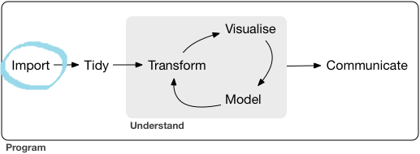

podemos usar/cargar datos de los paquetes

- Muchos paquetes de R contienen datos que podemos usar

… intenta entender el siguiente chunk de código

```r
#- cuando iniciamos R se cargan automáticamente un grupo de paquetes (R-base)
print(.packages()) #- [🌶]imprimimos los nombres de los "currently attached packages"

#- en uno de esos paquetes hay un conjunto de datos llamado "iris"
iris          #- llamamos a "iris"
find("iris")  #- [🌶] ¿donde está iris?
str(iris)     #- qué es iris?


my_iris <- iris  #- "hacemos una copia" de iris en el Global
find("my_iris")  #- ¿donde está my_iris?

iris <- c(2, 4)    #- creamos un vector llamado iris
find("iris")       #- ¿donde está ahora iris?
```

Tarea: usar unos datos de un paquete

- Tarea
- Pistas
- Solución
- Extended solution
- Quiero usar el conjunto de datos `flows` que está en el paquete [`refugees`](https://populationstatistics.github.io/refugees/)
- [`refugees`](https://cran.r-project.org/web/packages/refugees/index.html) es un paquete que no está en R-base
- Lógicamente, para poder usar esos datos, tenemos que tener instalado el paquete. Podemos hacerlo con `install.packages("refugees")`
- Después hay que cargar el paquete con `library(refugees)`
- Una vez hecho esto, ya podemos ver y usar el conjunto de datos `flows`

```r
library(refugees)

my_flows <- flows
```

**1**

Cargamos el paquete en el Global, en la memoria de R.  
Lógicamente antes hay que instalar el paquete con `install.packages("refugees")`.

**2**

Creamos un objeto llamado `my_flows` que es una “copia” de los datos en `flows`

```r
my_flows_2 <- refugees::flows
```

**1**

Es una forma alternativa de cargar los datos de `flows` sin cargar todo el paquete

# … seguimos importando

- Vamos a cargar en R datos que tenemos en nuestro ordenador
- Posiblemente, los hemos descargado previamente de la WEB

Los datos más habituales en Ciencias Sociales son los datos tabulares

- Hay múltiples formatos **tabulares**: `.csv`, `.xlsx`, `.sav` , `.dta`, etc …

Cuando carguemos/importemos esos datos tabulares en R …

- Se almacenarán internamente en R como **data.frames**

RStudio permite cargar datos usando menús.

- Usando menús (`File > Import Dataset`) se pueden cargar datos CSV, EXCEL, SPSS, SAS y STATA.
- Se puede hacer con menús, pero nosotros **usaremos código**

(La razón es que queremos que nuestros **análisis** sean **reproducibles**)

Para importar (y exportar) datos **utilizaremos código**

- **Usaremos funciones**, concretamente funciones del **paquete [rio](https://gesistsa.github.io/rio/index.html)** que permite importar y exportar ficheros en casi cualquier formato.
- Para importar datos en R usaremos la función `rio::import()`
- Para exportar datos en R usaremos la función `rio::export()`

importando datos con `rio::import()`

- La función `rio::import()` tiene varios argumentos, pero **solo usaremos el primero**.
- Su **primer argumento** se llama `file` y su descripción dice que … el valor de `file` ha de ser: “A character string naming a file, URL, or single-file .zip or .tar archive”. WTF!!
- Es decir, el **valor de `file`** ha de ser la **ruta** (de nuestro ordenador) donde están los datos que queremos importar
- Bueno, … en realidad también podemos importar directamente desde un “url”

Tarea: importar a R datos que tenemos guardados en nuestro ordenador

- Tarea
- Pistas
- Solución
- Extended solution
- ¿Te acuerdas de que antes hemos descargado unos datos en el fichero `./pruebas/plazas_turisticas.csv`?
- La tarea consiste en cargar esos datos en R (en el Global, en memoria de R)
- Has de usar la función `rio::import()`
- En su primer argumento (llamado `file`) has de especificar la ruta donde están los datos
- Recuerda que hemos guardado los datos en `"./pruebas/plazas_turisticas.csv"`

```r
my_ruta <- "./pruebas/plazas_turisticas.csv"

df <- rio::import(my_ruta)
```

**1**

Guardamos en `my_ruta` la ruta a los datos que quiero importar

**2**

Creamos un objeto llamado `df` con los datos que hay en `my_ruta`

```r
my_ruta <- "./pruebas/plazas_turisticas.csv"

df <- rio::import(file = my_ruta)
```

**1**

Esta vez ponemos tanto el nombre del argumento (`file`) como el valor del argumento (`my_ruta`)

Una vez tenemos los datos en R …

- … podemos comenzar a trabajar en nuestros datos; por ejemplo para limpiarlos

… imagina que alguien nos pide esos datos limpios

**¿Qué hacemos?**

- Tendremos que **exportar**/guardar los datos en un fichero de nuestro ordenador para poder enviárselos

# Exportación de datos

- Vamos a **exportar/guardar** en nuestro ordenador datos que tengamos en la memoria de R

Exportando datos en R con el paquete `rio`

- Para exportar datos en R usaremos la función `rio::export()`
- La función `rio::export()` tiene varios argumentos, pero **solo usaremos los dos primeros**.
1. El **primer argumento** se llama `x` (su valor ha de ser un objeto/datos de R que queremos exportar)
2. El **segundo argumento** se llama `file` (su valor ha de ser la ruta donde queremos guardar los datos)

Tarea: exportar unos datos de R a un fichero

- Tarea
- Pistas
- Solución
- Pregunta
- Tarea (II)
- Solución (II)
- Carga unos datos en R y expórtalos a un fichero en tu ordenador
- Por ejemplo, utiliza la función `rio::export()` para exportar a un fichero (de tu ordenador) el conjunto de datos **iris** en formato .csv
- Has de usar la función `rio::export()`
- Tienes que darle valores a dos argumentos de la función: `x` y `file`

(*) el valor de `x` ha de ser el objeto que quieres exportar (por ejemplo `iris`)

(*) el valor de `file` ha de ser la ruta donde quieres guardar los datos

```r
df <- iris

rio::export(df, "iris.csv")

rio::export(x = df,
            file = "iris.csv")
```

**1**

Cargamos los datos de `iris` en R: creamos el objeto `df`

**2**

Exportamos `df` a un fichero llamado `iris.csv`

**3**

Hace lo mismo que 2, pero ahora especificamos los nombres de los argumentos ( `x` y `file`) de la función `rio::export()`

- ¿Donde se ha guardado `iris.csv`?
- La respuesta es “en el directorio de trabajo”
- OK, pero, ¿exactamente donde?
- Como estamos trabajando en un Rproject, el directorio de trabajo es la propia carpeta del proyecto
- Por favor, guarda/graba `iris.csv` en la subcarpeta “pruebas” del Rproject

```r
rio::export(df, "./pruebas/iris.csv")

rio::export(x = df,
            file = "./pruebas/iris.csv")
```

Práctica: importar/exportar datos

- Práctica
- Solución
- Extensión(**)
1. Descarga (usando código) estos datos a tu ordenador: https://raw.githubusercontent.com/perezp44/iris_data/master/data/iris.csv
2. Importa a R esos datos que has descargado
3. Exporta los datos a formato `.xlsx` y `.rds`

Antes de empezar limpiamos la carpeta `pruebas` de nuestro proyecto

```r
fs::dir_delete("pruebas")
fs::dir_create("pruebas")
```

1. Descargando los datos

```r
#- en esta url hay un fichero de datos en formato .csv
my_url <- "https://raw.githubusercontent.com/perezp44/iris_data/master/data/iris.csv"

curl::curl_download(url = my_url,
                    destfile =  "./pruebas/iris.csv")
```

2. Importando los datos

```r
my_ruta <- "./pruebas/iris.csv"

iris <- rio::import(my_ruta)
```

3. Exportando los datos

```r
rio::export(x = iris, file = "./pruebas/iris.xlsx")

rio::export(x = iris, file = "./pruebas/iris.rds")
```

- Veremos que … para gestionar/construir nuestras rutas, es conveniente usar `here::here()`
- La razón es que favorecerá que nuestros análisis sean reproducibles

```r
here::here()
```

**1**

`here::here()` devuelve la ruta al directorio de trabajo  
Como trabajamos con Rproject’s, entonces devuelve la ruta a la carpeta del Rproject en **tú ordenador**.  
Esto nos será útil cuando trabajemos con ficheros `.qmd`

- Lo veremos más adelante en una extensión

# Formatos de datos propios de R

- R tiene 2 formatos de datos propios: `.rda` y `.rds`

Formatos de datos propios de R

- Guardar datos en formatos como `.csv` o `.xlsx` es lo más habitual si quieres abrir estos datos en otros programas, pero …
- … pero al grabar en estos formatos guardas los datos, PERO no guardas los metadatos!!!

R tiene 2 formatos de datos propios: `.rda` y `.rds`

- Estos formatos **sí guardan los metadatos**

Formato .rds

- **Exportar** datos a formato `.rds`

```r
rio::export(x = iris, file = "./pruebas/iris.rds")
```

**Extensión**: dos formas alternativas de exportar a `.rds` (😱😱)

(Sí, en R se pueden hacer las cosas de muchas maneras!!! 🚨🚨)

```r
saveRDS(iris, file = "./pruebas/iris.rds")        #- con base-R

readr::write_rds(iris, "./pruebas/iris.rds")      #- con pkg "readr"
```

- **Importar** datos en formato `.rds`

```r
df <- rio::import(file = "./pruebas/iris.rds")
```

**Extensión**: dos formas alternativas de importar `.rds`

(Sí, en R se pueden hacer las cosas de muchas maneras!!! 🚨🚨)

```r
my_iris_1 <- readRDS("./pruebas/iris.rds")         #- con R-base

my_iris_2 <- readr::read_rds("./pruebas/iris.rds")  #- tidyverse
```

Formato .RData (o .rda)

- El formato `.RData` tiene la ventaja de que puedes guardar varios objetos a la vez
- Para **exportar** datos a formato `.rda`

```r
#- guardamos los objetos mtcars e iris en un fichero llamado "mtcars_and_iris.RData"

save(mtcars, iris,  file = "./pruebas/mtcars_and_iris.RData")
```

- Para **importar** datos en formato `.rda`, tenemos que usar la función `load()`

```r
load(file = "./pruebas/mtcars_and_iris.RData")
```

- **Extensión:** Para importar `.rda` desde la web hay que usar `load(url())`

```r
#- hay que usar load(url())
#- no funciona xq han borrado el archivo
df <- load(url("http://gedemced.uab.cat/images/POP_ENC_AMB_2014.Rdata"))

#- pero si aún así no funcionase, usa  repmis::source_data()
my_url <- "https://github.com/perezp44/LAU2boundaries4spain/blob/master/data/Provincias.rda?raw=true"
df <- load(url(my_url)) #- no funciona
df <- repmis::source_data(my_url)
```

# Acceder a datos a través de API’s

- Hay muuuuuchas organizaciones que ofrecen datos a través de API’s y …
- … en muchas ocasiones, hay un paquete de R para acceder fácilmente a ellos!!!

Eurostat

- [Eurostat](https://ec.europa.eu/eurostat) es la oficina de estadística de la Unión Europea
- El paquete [`eurostat`](https://ropengov.github.io/eurostat/) permite acceder a las API’s de Eurostat para obtener datos
- Por ejemplo [aquí](https://ec.europa.eu/eurostat/databrowser/view/cult_emp_sex/default/table?lang=en) puedes ver una de las múltiples tablas de datos que ofrece Eurostat; concretamente la tabla Cultural employment by sex o con siglas **“cult_emp_sex”**
- ¿Importamos esa tabla a R con el paquete `eurostat`?

```r
# install.packages("eurostat")
library(eurostat)

#- importamos los datos de la tabla "cult_emp_sex": "Cultural employment by sex"
df <- eurostat::get_eurostat("cult_emp_sex")
```

Practica: importar datos de Eurostat

- Podemos buscar un tema en Eurostat; por ejemplo [aquí](https://ec.europa.eu/eurostat/web/lfs/database) hay datos de “Employment and unemployment (LFS)”, [aquí](https://ec.europa.eu/eurostat/statistics-explained/index.php?title=Population_and_social_conditions) datos sobre “Population and social conditions” y [aquí](https://ec.europa.eu/eurostat/web/crime/database) sobre “Crime and criminal justice”
- Para mi es más cómodo buscar datos con el paquete `eurostat`. ¿Probamos?

```r
library(eurostat)

#- podemos buscar un  "tema" con la f. search_eurostat()
my_tema <- "employment"

aa <- eurostat::search_eurostat(pattern = my_tema, type = "all")

#- elegimos un dataset; por ejemplo "hlth_silc_17"
my_table <- "hlth_silc_17"

#- da información sobre la Base de datos que estas buscando
eurostat::label_eurostat_tables(my_table)

#-  importamos los datos de "my_table" con get_eurostat()
df <- eurostat::get_eurostat(my_table, time_format = "raw", keepFlags = TRUE )

#- pedimos los descriptores/labels de las series
df_l <- eurostat::label_eurostat(df)
```

El paquete [`quantmod`](http://www.quantmod.com/)

- Permite acceder a una gran variedad de datos económicos. [Aquí](https://www.quantmod.com/examples/intro/) tienes información

```r
library(quantmod)  #- install.packages("quantmod")

#- For stocks and shares, the yahoo source is used.
facebook  <- getSymbols(Symbols = 'F', src = 'yahoo', auto.assign = FALSE)
barChart(facebook)

#- For currencies and metals, the oanda source is used.
tc_euro_dolar <- getSymbols(Symbols = 'EUR/USD', src = 'oanda', auto.assign = FALSE)

#- For economics series, the FRED source is used.
Japan_GDP <- getSymbols(Symbols = 'JPNNGDP', src = 'FRED', auto.assign = FALSE)
```

# Algunos BONUS de I/O

- Con lo que hemos visto hasta ahora nos apañamos, pero conviene ver alguna cosa más …

Bonus 1 (🌶🌶 … 🌶): exportar los datos de un df a un archivo `.xlsx` ya existente

- Solución (I)
- Solución (II)

```r
#- bonus: le añadimos un libro mas al archivo "./pruebas/iris.xlsx"

rio::export(iris, "./pruebas/iris.xlsx")  #- por si acaso lo hubiésemos borrado


rio::export(iris, "./pruebas/iris.xlsx", which = "iris_2")

#- lo mismo pero poniendo los nombres de los argumentos
rio::export(x = iris,
           file ="./pruebas/iris.xlsx",
           which = "iris_3")
```

- Esta solución ya no funciona 😱 !!
- Tendremos que usar nuevo paquete: `openxlsx`

```r
#- tenemos que usar el pkg openxlsx
library(openxlsx) #- pak::pak("openxlsx")

#- tenemos que crear un "Woorkbook" con la f. loadWorkbook()
my_workbook <- openxlsx::loadWorkbook("./pruebas/iris.xlsx")

#- ahora añadimos hojas/sheets al Woorkbook
openxlsx::addWorksheet(my_workbook, "iris_2")
openxlsx::addWorksheet(my_workbook, "my_mtcars")

#- ahora escribimos datos en las nuevas hojas/sheets q hemos creado
openxlsx::writeData(my_workbook, sheet = "iris_2",    x = iris)
openxlsx::writeData(my_workbook, sheet = "my_mtcars", x = mtcars)

#- exportamos/guardamos el archivo (con las nuevas sheets)
openxlsx::saveWorkbook(my_workbook, "./pruebas/iris.xlsx", overwrite = TRUE)
```

Bonus 2 (🌶🌶🌶): exportar 2 df’s en un único archivo `.xlsx`

- Seguimos usando el paquete `rio`, pero …

… los objetos que queremos exportar se incluyen dentro de la función `list()`

```r
rio::export(x = list(my_iris = iris, my_pinguinos = penguins),
            file = "./pruebas/my_iris_pinguinos.xlsx")
```

Bonus 3 (🌶🌶): importar una hoja/libro especifica de un archivo `.xlsx`

- Seguimos usando el paquete `rio`, pero …

… tenemos que usar un nuevo argumento: `sheet`

```r
iris_1 <- rio::import("./pruebas/my_iris_pinguinos.xlsx")  #- solo importa el primer libro


pinguinos_1 <- rio::import("./pruebas/my_iris_pinguinos.xlsx", sheet = 2)


pinguinos_2 <- rio::import(file = "./pruebas/my_iris_pinguinos.xlsx",
                           sheet = "my_pinguinos")
```

Bonus 4: (!!!! 😱 😱) importamos todos los libros de un archivo `.xlsx`

```r
library(readxl) #- necesitamos la función readxl::excel_sheet()

mys_sheets <- readxl::excel_sheets(here::here("pruebas", "my_iris_pinguinos.xlsx"))

#- con base::lapply()
my_dfs_list <- lapply(mys_sheets,
                      readxl::read_excel,
                      path = here::here("pruebas", "my_iris_pinguinos.xlsx"))
#- con purrr::map()
my_dfs_list <- purrr::map(mys_sheets,
                           readxl::read_excel,
                           path = here::here("pruebas", "my_iris_pinguinos.xlsx"))
```

- Ok, pero ahora tenemos los 2 data.frames dentro de una lista ¿qué hacemos?

```r
#- Extrayendo un data.frame de una lista: con [[]]
my_iris <- my_dfs_list2[[1]]
```

Bonus 5: (!!!!!!) importamos todos archivos de datos de una carpeta concreta

```r
#- importamos todos los archivos que hemos creado en "./pruebas/"
library(purrr)
my_carpeta <- here::here("pruebas")

lista_de_archivos <- fs::dir_ls(my_carpeta)

my_dfs_list_2 <- map(lista_de_archivos, rio::import)
```

- Ya veremos, con un ejemplo, cómo podemos juntar todos los df’s en un único data.frame

# Extensiones

Webscrapping [🌶🌶🌶 🌶🌶]

- **Webscrapping** consiste en obtener datos directamente de páginas web, de su código html.

Webscrapping (ejemplo 1)

- En [esta página web](https://es.wikipedia.org/wiki/Anexo:Municipios_de_la_provincia_de_Teruel) hay una tabla con los pueblos más “altos” de Teruel
- Para obtener esos datos en R, podemos usar el paquete `rvest`

```r
library(rvest)
library(tidyverse)
my_url <- "https://es.wikipedia.org/wiki/Anexo:Municipios_de_la_provincia_de_Teruel"
content <- read_html(my_url)

body_table <- content %>%
              html_nodes('body')  %>%
              html_nodes('table') %>%
              html_table(dec = ",")

#- solo hay una tabla
Teruel <- body_table[[1]]  #- estoy haciendo subsetting de una lista
```

- Podemos arreglar un poco la tabla (!!!!!!!!)

```r
names(Teruel) <- c("Nombre",  "Poblacion", "Superficie",
                   "Densidad", "Altitud", "Comarca", "Partido_judicial")
library(stringr)
Teruel <- Teruel %>% map(str_trim) %>% as_tibble() #- quita caracteres al final
Teruel <- Teruel %>% mutate(Altitud = str_replace_all(Altitud,"[[:punct:]]", ""))
Teruel <- Teruel %>% mutate(Altitud = as.double(Altitud)) %>% arrange(desc(Altitud))
```

digresión: es lo mismo un data.frame que una tibble [🌶🌶🌶]

Sí y no (!!!)

- No son exactamente lo mismo, pero para nosotros son totalmente equivalentes. Podemos pensar que las **tibbles** son data.frame’s modernizados o tuneados
- Las dos son estructuras de R para almacenar datos tabulares. Si quieres ver en qué se diferencian lee [esto](https://tibble.tidyverse.org/).

Veámoslo un poco:

```r
typeof(iris)
```

```
[1] "list"
```

```r
class(iris)
```

```
[1] "data.frame"
```

```r
names(attributes(iris))
```

```
[1] "names"     "class"     "row.names"
```

Convertimos `iris` en `tibble`:

```r
iris_2 <- tibble::as_tibble(iris)
```

```r
typeof(iris_2)
```

```
[1] "list"
```

```r
class(iris_2)
```

```
[1] "tbl_df"     "tbl"        "data.frame"
```

```r
names(attributes(iris_2))
```

```
[1] "class"     "row.names" "names"
```

- Alguna funciones antiguas puede que no funcionen con tibbles. Si te pasa esto, tienes que usar `as.data.frame()`. Puedes leerlo [aquí](https://r4ds.had.co.nz/tibbles.html)

seleccionando “manualmente” un archivo de datos

- Este truco es chulo … pero no hay que hacerlo

```r
my_data <- rio::import(file.choose())
```

- No hay que hacerlo si queremos que nuestros análisis sean reproducibles

gestionando las rutas con `here::here()`

Problemas con las rutas “tradicionales”

- **Rutas absolutas son “frágiles”**
  - `C:\tu-usuario\tu-proyecto\datos\archivo.csv`
  - No funcionarán en otras máquinas
- **Rutas relativas pueden ser ambiguas:**
  - `"./datos/archivo.csv"` o `"../scripts/codigo.R"`
  - ¿Relativas a qué? Depende de dónde ejecutes!!
- **Consecuencias:**
  - Scripts no reproducibles.
  - “Error: No se puede encontrar el archivo”

En realidad, como nosotros trabajamos con Rstudio y con Rproject’s, de momento nos basta con utilizar rutas relativas, **PERO**, esto cambiará cuando trabajemos con archivos `.qmd`

Rutas con `here::here()`

- Construye rutas **absolutas**, PERO estas rutas absolutas no se construyen a mano, sino cuando se ejecuta el código; por lo tanto, como trabajamos con Rproject’s, esas rutas absolutas funcionarán tanto si trabajamos con ficheros `.R` como con ficheros `.qmd`
- Como nosotros trabajamos con Rproject’s, las rutas relativas que vayamos construyendo serán rutas **relativas a la carpeta raíz de tu Rproject**, y `here::he()` las convertirá en rutas absolutas. Por ejemplo:

```r
my_ruta <- here::here("datos", "my_archivo.csv")
```

`C:\Users\my_usuario\my_Rproject\datos\my_archivo.csv`

- **Ventajas:**
  - **Reproducible**: funcionará en cualquier ordenador
  - Genera rutas absolutas **pero** específicas para cada ordenador
- ➡ Olvídate de `setwd()` al inicio!! Tu yo futuro y tus coautores te lo agradecerán!! ✨

¿cómo construir nuestra rutas con `here::here()`?

- Recuerda que si queríamos exportar el fichero `iris`, hacíamos algo como:

```r
rio::export(iris, file = "./pruebas/iris.xlsx" )
```

- Para hacer los mismo con `here::here()` haremos:

```r
rio::export(iris, file = here::here("pruebas", "iris.xlsx" ))
```

- Fíjate que `here::here()` nos devuelve una ruta absoluta, pero diferente para cada ordenador:

```r
here::here("pruebas", "iris.xlsx" )
```

```
C:\my_usuario\my_proyecto\pruebas\iris.xlsx
```

(si quieres leer sobre ello puedes hacerlo [aquí](https://whyherepkg.netlify.app/#1) y [aquí](https://joshua.wilsonblack.nz/posts/organising-r-projects/#r-project-files-and-the-here-package))

(si quieres leer sobre gestión de rutas en R puedes hacerlo [aquí](https://albert-rapp.de/posts/36_fs_package/), [aquí](https://blog.djnavarro.net/posts/2024-10-06_fs/) y [aquí](https://comunidadbioinfo.github.io/cdsb2021_workflows/paths-seguros.html))

vamos a usar un bucle `for` … para exportar varios archivos

- Imagina que quiero **exportar un fichero**, por ejemplo `iris`, a **varios formatos** y quiero hacerlo con un “for loop”
- Tarea
- Solución
- Exporta `iris` a los formatos `.csv`, `.xlsx` y `.dta` usando un bucle `for`.
- Esta vez no hay solución 😧 !!
- Bueno … la solución estará en uno de los ejemplos del Rproject del curso. ¿Lo veremos?

no siempre es fácil publicar bien unos datos

- Por ejemplo [este tweet](https://twitter.com/jescuderoma/status/1375030727373430789/photo/1)

[figure not shown]

- Una [guía](https://datos.gob.es/es/documentacion/guia-practica-para-la-publicacion-de-datos-tabulares-en-archivos-csv) para publicar datos en .csv. [Aquí](https://datos.gob.es/sites/default/files/doc/file/cheat_sheet_csv_vf.pdf) la cheatsheet
- Un [buen post](http://r4stats.com/2018/03/28/using-excel-for-data-entry/) sobre la misma temática

algunas referencias

- El [capítulo](https://r4ds.hadley.nz/data-import.html) de importación de datos de R4DS(2ed).
- El [capítulo](https://r4ds.had.co.nz/data-import.html) de importación de datos de R4DS.
- Un [buen capítulo](https://ubc-dsci.github.io/introduction-to-datascience/reading.html) sobre importación de datos en R.
- Unas [buenas transparencias](https://stats220.earo.me/02-import-export.html#1) de Earo Wang. [Aquí](https://stats220.earo.me/pages/data/) están sus datos.

# Un caso más complejo

- Resulta que quiero saber que provincia tiene más municipios, así que vamos a ir al INE, concrétamente [aquí](https://www.ine.es/daco/daco42/codmun/codmunmapa.htm). En esa página hay un fichero que nos permitirá contar el nº de municipios

un caso más complejo

- Tarea
- Sol (con rio)
- Sol (por menús)
- Sol (con `readxl`)
- Sol (pofesional) [🌶🌶🌶🌶🌶]

Para contar el nº de municipios por provincia tenemos que descargar el fichero con la relación de municipios del INE. El fichero está aquí: https://www.ine.es/daco/daco42/codmun/codmun20/20codmun.xlsx

- Vamos a descargarlo de varias formas:
  1. con el paquete `rio`
  2. utilizando los menús de RStudio
  3. con el paquete `readxl`
  4. Finalmente lo haremos de forma más “pofesional”

```r
rm(list = ls())  #- antes vamos a limpiar el Global env.

my_url <- "https://www.ine.es/daco/daco42/codmun/codmun20/20codmun.xlsx"

my_ruta_guardar <- here::here("pruebas", "20codmun.xlsx")

curl::curl_download(my_url, my_ruta_guardar) #- lo guardo en disco

df_1 <- rio::import(my_ruta_guardar) #- q pb tenemos?
```

- Vamos a usar menús, pero que no nos vea Hadley!!!
- Seguid la siguiente ruta de menús: `File > Import Dataset > From Excel ...`
- Pegáis en la caja de texto el `url` y pincháis el botón `update`

```r
df_2 <- readxl::read_xlsx(my_url, skip = 1)  #- no funciona. readxl solo lee del PC

my_ruta_guardar <- here::here("pruebas", "20codmun.xlsx")

df_2 <- readxl::read_xlsx(my_ruta_guardar, skip = 1)
```

```r
#- script para bajar la relación de municipios INE a 1 de enero de 2021
url_descarga <- "https://www.ine.es/daco/daco42/codmun/diccionario21.xlsx"
nombre_fichero <- "diccionario21.xlsx"

#- obtengo el nombre del archivo
nombre_fichero <- stringr::str_extract(url_descarga, "([^\\/]+$)")

#- añado la fecha de descarga al nombre de archivo
extension <- stringr::str_extract(url_descarga, "([^\\.]+$)")
nombre <- stringr::str_remove(nombre_fichero, paste0(".",extension))
nombre_fichero <- paste0(nombre , "_", Sys.Date(), ".", extension)

#- lo guardo
my_ruta <- here::here("pruebas", nombre_fichero) #- ruta para guardar el fichero
curl::curl_download(url = url_descarga, destfile = my_ruta)
```

- Importo el fichero a la memoria de R

```r
df <- readxl::read_xlsx(path = my_ruta, skip = 1)

#- la verdad es que skip = 1 también hubiese funcionado con el paquete `rio`
#- ya que `rio` llama a `readxl`
```

seguimos con el ejemplo

aparecen muchas cosas/funciones que veremos más adelante [🌶🌶🌶🌶]

- Arreglo los datos a mi gusto

```r
library(tidyverse)

df <- df %>%
      mutate(ine_muni = paste0(CPRO, CMUN)) %>%
      mutate(year = "2021") %>%          #- !! cómo lo guardaría?
      mutate(year = as.numeric(year)) %>%
      rename(ine_muni.n = NOMBRE) %>%
      rename(ine_prov = CPRO) %>%
      select(ine_muni, ine_muni.n, ine_prov, year)

str(df)
```

- Si quisiera exportar el archivo

```r
readr::write_csv(df, file = here::here("pruebas", "my_relacion_muni_2021.csv"))
```

- Podemos contar el nº de municipios por provincia (de muchas maneras distintas)

```r
df_muni <- df %>% group_by(ine_prov) %>% summarise(numero_muni = n())
df_muni <- df %>% count(ine_prov)
```

- Si quisiéramos saber el nombre de las provincias

```r
#- pak::pak("perezp44/pjpv.curso.R.2022")
codigos_prov <- pjpv.curso.R.2022::ine_pob_mun_1996_2021 %>%
                select(ine_prov, ine_prov.n) %>%
                distinct()
```

- Para fusionar los 2 ficheros

```r
#- fusiono los 2 ficheros (lo veremos!!)
df_ok <- left_join(df_muni, codigos_prov)
```

- Borro la carpeta (para dejar el Rproject limpio)

```r
fs::dir_delete("pruebas")  #- [🌶] borro la carpeta pruebas
```

# Más extensiones

- funciones, paquetes, etc …

quizás 🤔 … lo más importante del curso sea entender bien cómo “funciona” una función

- Sí, es muy importante entender qué es y cómo usar una función
- De hecho, todo lo que ocurre, todo lo que pasa en R es porque has llamado a una función
- Again: si algo ocurre en R es porque has hecho una llamada a una función, una “function call”

> To understand computations in R, two slogans are helpful:  
> - Everything that exists is an object.  
> - Everything that happens is a function call.

> — John Chambers (creador de S)
- Usar funciones permite:
  - reutilizar código y organizar los programas de manera más eficiente
  - facilita la depuración de errores y el mantenimiento
  - mejora la legibilidad del código

**¿qué es una función?**

- Una función no es más un trozo de código R, unas instrucciones de R, a las que les hemos puesto/asignado un nombre; entonces, cuando invoquemos ese nombre, esa función, se ejecutarán esas lineas de código y nos devolverá un resultado

(Como no creo que lo anterior os diga mucho, vamos a usar 5 minutos para crear nuestra primera función)

creamos nuestra primera función

- Tarea
- Pistas
- Solución

Crea una función que permita sumar 2 números

- Las funciones en R se crean con la función llamada `function()`. Sí, un poco trabalenguas.
- La función que vamos a crear será un objeto de R, así que le tenemos que asignar un nombre
- Los argumentos de la función van dentro de los paréntesis separados por comas
- El código que queramos que se ejecute cuando llamemos a la función va entre llaves

Por lo tanto, en genérico, **una función en R se crea así**:

```
nombre_de_mi_funcion <- function(argumento_1, argumento_2, ...) {
  <codigo-q-quiero-q-se-ejecute-cuando-se-invoque-a-la-función>
}
```

(Sí lo conseguís sois genios o ya habéis visto esto en otro lenguaje)

- Creamos una función llamada `my_f_suma()`
- Para ello, usamos la función de R llamada `function()`

```r
my_f_suma <- function(n1 , n2){
  n1 + n2
}
```

- Para usar la función que hemos creado:

```r
my_f_suma(3 , 5)
my_f_suma(n1 = 3 , n2 = 5)

aa <- my_f_suma(30 , 50)
```

supongo que ahora se entiende mejor qué es una función?

- Recuerda, no es más que un trozo de instrucciones/código en R que alguien ha creado para ser usada
- Para usarlas, solo tenemos que invocar su nombre y dar valores a sus argumentos

seguimos con las funciones

- Vamos a profundizar en nuestro conocimiento de las funciones usando una: usando la función `sqrt()`
- Resulta que alguien se ha preocupado de construir una función llamada `sqrt()` que sirve para calcular raíces cuadradas. Vamos a usarla!! Cómo??

ejemplo: cómo aprender a usar `sqrt()`

- Para usar una función puedes buscar en internete, pedir ayuda a una IA, etc … pero creo que mejor si usas la ayuda oficial de la función
- Sí cada función de R tiene una página de ayuda interna.
- Para abrir la ayuda oficial hay que situar el cursor en el nombre de la función y pinchar en `F1`
- También puedes hacer: `help(sqrt)`

ayuda oficial de `sqrt()`

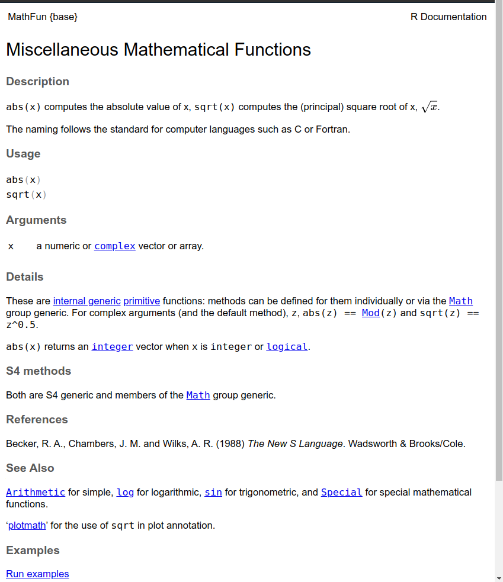

- La ayuda oficial parece muy complicada, pero hay que aprender a leer las ayudas de las funciones. **Es es MUY IMPORTANTE!!!!** si quieres aprender a manejarte con R.

vamos a usar `sqrt()` para aprender cómo usar funciones

**Tarea:** ejecuta estas instrucciones e intenta entender que ocurre

```r
sqrt(9)
sqrt(9, 4)   #- no funciona ¿por qué? ¿cuantos argumentos tiene la f. sqrt()?
sqrt("9")    #- no funciona, ¿por qué? ¿Cómo, de que tipo, ha de ser el argumento?
```

… más detalles

- En realidad, cuando vamos a usar una función, **cada argumento de la función tiene 2 elementos**: el **nombre** del argumento y un **valor** para el argumento
- El nombre de la función sqrt() es `sqrt`, ok, pero ¿cuales son sus argumentos? La ayuda nos dice que sólo tiene un argumento, cuyo nombre es `x` ; además, el valor del argumento debe ser numérico

```r
sqrt(9)       #- en realidad "no hace falta" poner el nombre del argumento
sqrt(x = 9)   #-
sqrt(x = 4)
```

hay que diferenciar el nombre y el valor del argumento de una función

```r
x <- 25
sqrt(x)

sqrt(x = x)          #- !!!

sqrt(x = un_valor)   #- !!!
sqrt(nn = 9)         #- !!!
```

seguimos con las funciones (ya casi lo tenemos!!)

- Tarea
- Solución
- Calcula el logaritmo de 1000 en base 10. Para ello tenéis que usar la función `log()`
- Cómo no sabemos cómo se usa, no sabemos cómo es su sintaxis, no sabemos cuales son sus argumentos, nos va a tocar **mirar la ayuda de la función**
- `log(1000)` no va a funcionar. ¿Por qué? para saberlo tendrás que mirar la ayuda de la función `log()`

Esto no funciona:

```r
log(1000)  #- como no especificamos el valor del argumento "base",
           #- R lo fija a su valor x defecto; es decir, base = exp(1)
           #- así que estamos tomando logaritmos naturales
```

Varias soluciones:

```r
log(x = 1000, base = 10)    #- GOOD

log(1000, base = 10)        #- es equivalente
log(x = 1000, 10)           #- es equivalente
log(1000, 10)               #- es equivalente

log(1000, bas = 10)         #- funciona, pero ... mejor no hacerlo
```

¿Por qué no podemos usar la expresión de abajo?

```r
log(10, 1000)
```

¿Funcionará?

```r
log(base = 10, 1000)
```

… lo ultimísimo sobre funciones

- ¿Qué hacen los siguientes chunks?

```r
add1 <- function(my_number) {
  my_number + 1
}
```

```r
my_suma_3a <- function(n1 , n2, n3){
   n1 + n2 + n3
}

#- vamos a usar nuestra función
my_suma_3a(2)        #- xq no funciona?
```

```r
my_suma_3b <- function(n1 = 4 , n2 = 6, n3 = 3){
   n1 + n2 + n3
}

my_suma_3b(2)        #- xq ahora sí funciona?
```

- Estaría bien que le pegaseis un vistazo a [este apéndice](https://socviz.co/appendix.html#a-little-more-about-r) sobre cómo leer las ayudas de las funciones en R